# Course Project #4

Danica Espanola, Xyza Maagad

May 25, 2019

## Programming Assignment (Exploratory Graphs)

```r
## Setting working directory
setwd("C:/Users/Client/Desktop/xyza/197 Data Science/projects/4")
```

```r
## Accessing and reading files in R
NEI <- readRDS("summarySCC_PM25.rds")
SCC <- readRDS("Source_Classification_Code.rds")
```

### Question 1

Have total emissions from PM2.5 decreased in the United States from 1999 to 2008? Using the base plotting system, make a plot showing the total PM2.5 emission from all sources for each of the years 1999, 2002, 2005, and 2008.

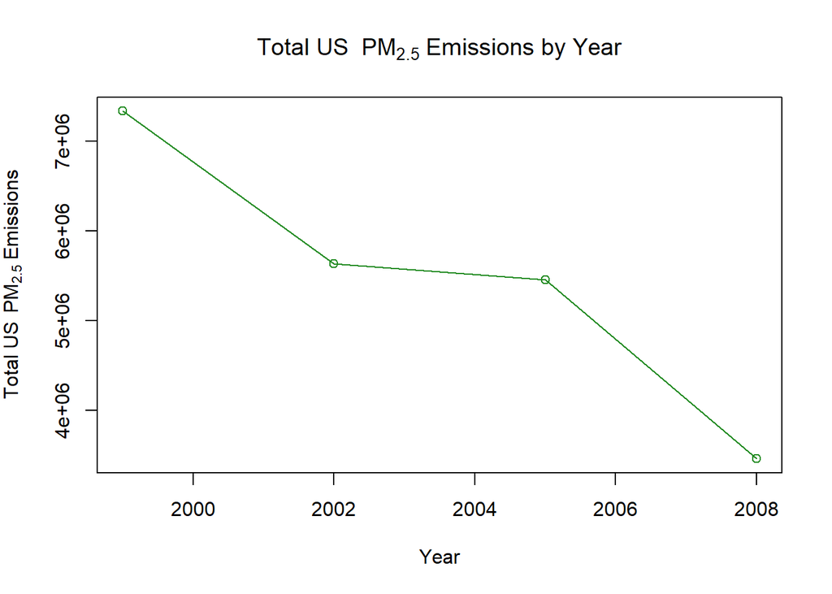

```r
NEI2 <- aggregate(Emissions ~ year, NEI, sum)

plot(NEI2$year, NEI2$Emissions, type = "o", col = "forestgreen",
     main = expression("Total US "~ PM[2.5]~ "Emissions by Year"),
     ylab = expression("Total US "~   PM[2.5] ~ "Emissions"),
     xlab = "Year")
```

### Question 2

Have total emissions from PM2.5 decreased in the Baltimore City, Maryland (fips == “24510”) from 1999 to 2008? Use the base plotting system to make a plot answering this question.

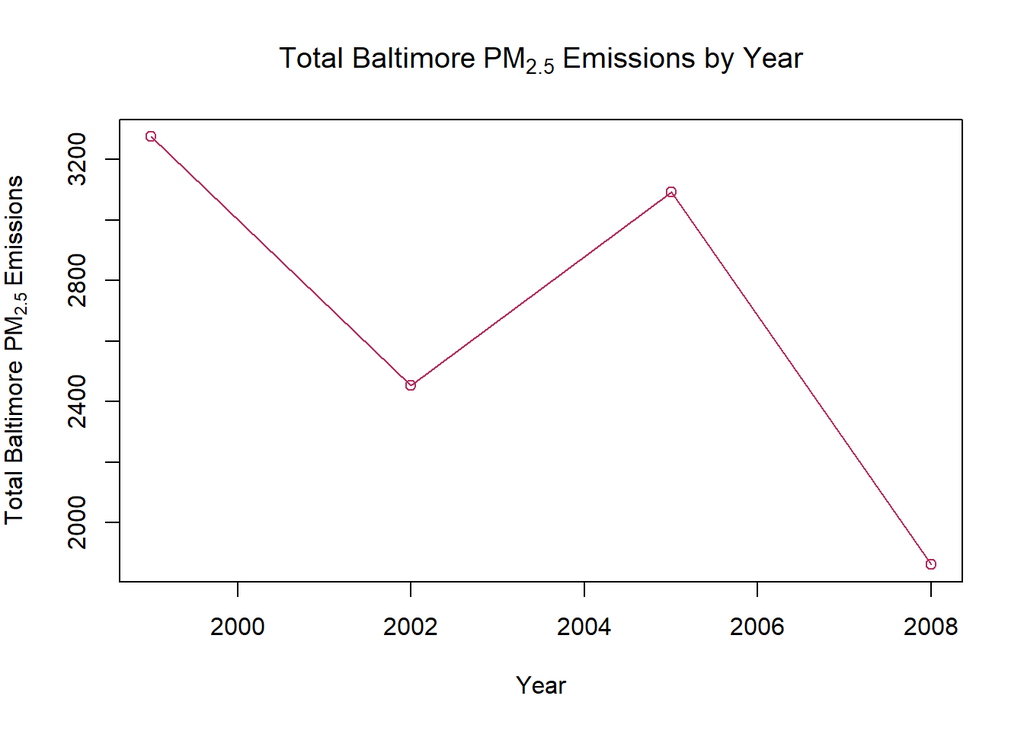

```r
baltimore <- subset(NEI, NEI$fips == "24510")

totalBaltimore <- aggregate(Emissions ~ year, baltimore, sum)

plot(totalBaltimore$year, totalBaltimore$Emissions, type = "o", col = "maroon",
     main = expression("Total Baltimore" ~ PM[2.5] ~ "Emissions by Year"),
     ylab = expression("Total Baltimore "~ PM[2.5] ~ "Emissions"),
     xlab = "Year")
```

### Question 3

Of the four types of sources indicated by the type (point, nonpoint, onroad, nonroad) variable, which of these four sources have seen decreases in emissions from 1999-2008 for Baltimore City? Which have seen increases in emissions from 1999-2008? Use the ggplot2 plotting system to make a plot answer this question.

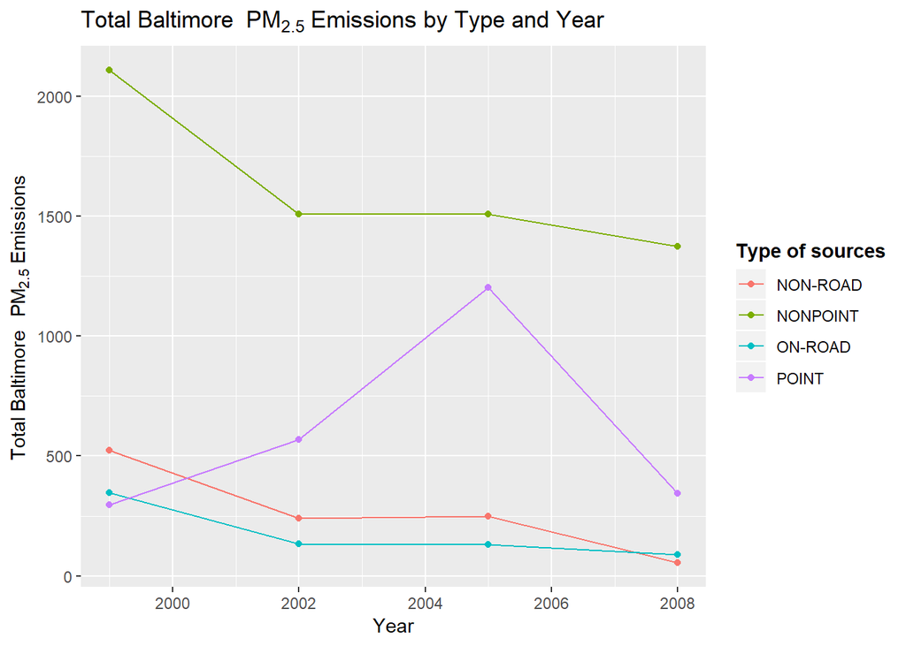

```r
library(ggplot2)
baltimore <- subset(NEI, NEI$fips == "24510")
baltimoreType <- aggregate(Emissions ~ year + type, baltimore, sum)

ggplot(baltimoreType, aes(year, Emissions, col = type)) +
    geom_line() +
    geom_point() +
    ggtitle(expression("Total Baltimore " ~ PM[2.5] ~ "Emissions by Type and Year")) +
    ylab(expression("Total Baltimore " ~ PM[2.5] ~ "Emissions")) +
    xlab("Year") +
    scale_colour_discrete(name = "Type of sources") +
    theme(legend.title = element_text(face = "bold"))
```

### Question 4

Across the United States, how have emissions from coal combustion-related sources changed from 1999-2008?

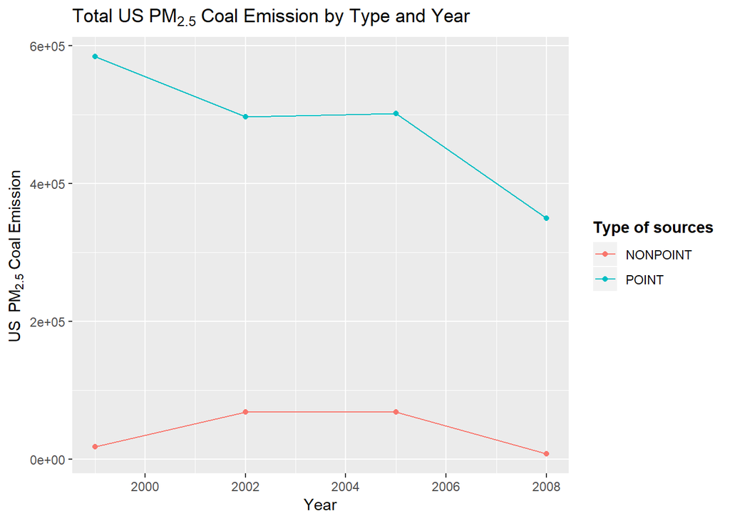

```r
SCCcoal <- SCC[grepl("coal", SCC$Short.Name, ignore.case = T),]
NEIcoal <- NEI[NEI$SCC %in% SCCcoal$SCC,]
totalCoal <- aggregate(Emissions ~ year + type, NEIcoal, sum)

ggplot(totalCoal, aes(year, Emissions, col = type)) +
    geom_line() +
    geom_point() +
    ggtitle(expression("Total US" ~ PM[2.5] ~ "Coal Emission by Type and Year")) +
    xlab("Year") +
    ylab(expression("US " ~ PM[2.5] ~ "Coal Emission")) +
    scale_colour_discrete(name = "Type of sources") +
    theme(legend.title = element_text(face = "bold"))
```

### Question 5

How have emissions from motor vehicle sources changed from 1999-2008 in Baltimore City?

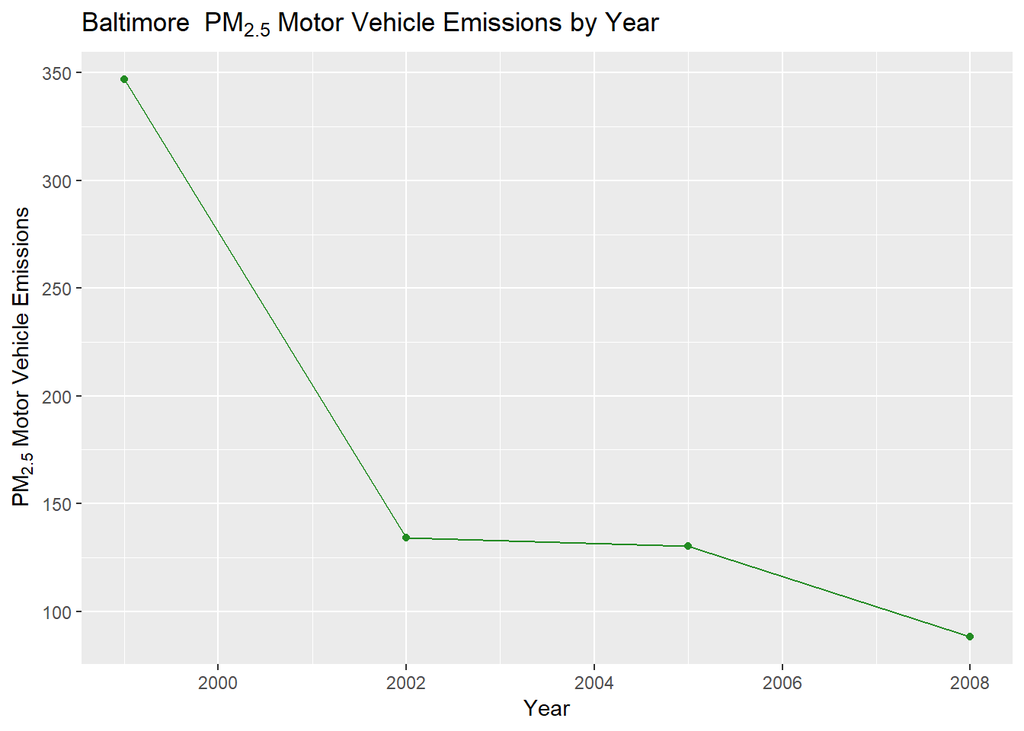

```r
baltimoreMotor <- subset(NEI, NEI$fips == "24510" & NEI$type == "ON-ROAD")
baltimoreMotorAGG <- aggregate(Emissions ~ year, baltimoreMotor, sum)

ggplot(baltimoreMotorAGG, aes(year, Emissions)) +
    geom_line(col = "forestgreen") +
    geom_point(col = "forestgreen") +
    ggtitle(expression("Baltimore " ~ PM[2.5] ~ "Motor Vehicle Emissions by Year")) +
    xlab("Year") +
    ylab(expression(~PM[2.5]~ "Motor Vehicle Emissions"))
```

### Question 6

Compare emissions from motor vehicle sources in Baltimore City with emissions from motor vehicle sources in Los Angeles County, California (fips == “06037”). Which city has seen greater changes over time in motor vehicle emissions?

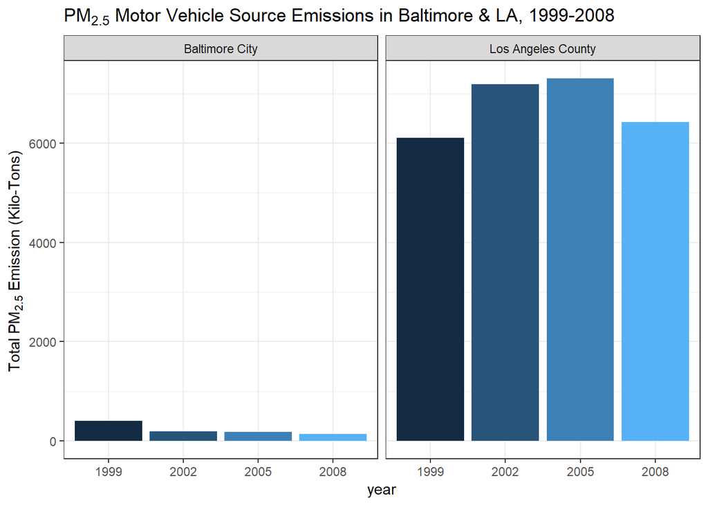

```r
vehicles <- grepl("vehicle", SCC$SCC.Level.Two, ignore.case=TRUE)
vehiclesSCC <- SCC[vehicles,]$SCC
vehiclesNEI <- NEI[NEI$SCC %in% vehiclesSCC,]

baltimore <- vehiclesNEI[vehiclesNEI$fips == 24510,]
baltimore$city <- "Baltimore City"
lacali <- vehiclesNEI[vehiclesNEI$fips=="06037",]
lacali$city <- "Los Angeles County"
NEIBothCity <- rbind(baltimore, lacali)

ggplot(NEIBothCity, aes(x=factor(year), y=Emissions, fill=city)) +
    geom_bar(aes(fill=year),stat="identity") +
    facet_grid(scales="free", space="free", .~city) +
    guides(fill=FALSE) + theme_bw() +
    labs(x="year", y=expression("Total PM"[2.5]*" Emission (Kilo-Tons)")) +
    labs(title=expression("PM"[2.5]*" Motor Vehicle Source Emissions in Baltimore & LA, 1999-2008"))
```